# act_report

### Prepared By: Ashley Mahaffey

### Introduction

This report delves into the insights derived from a comprehensive analysis of the "WeRateDogs" Twitter archive. The analysis encompassed data gathering, assessing, and cleaning to uncover valuable patterns and trends.

### 1. Distribution of Dog Stages

A pie chart presenting the distribution of dog stages, with "pupper" being the most common stage, followed by "doggo." This visual provides a clear breakdown of the popularity of different dog stages in the WeRateDogs dataset.

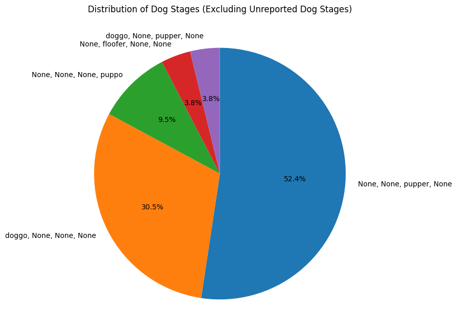

```python
from IPython import display
display.Image("./Dist of Dog Stages.png")
```

### 2. Distribution of Rating Numerators

This bar chart visualizes the frequency of different rating numerators, emphasizing the prevalence of ratings around the 12/10 mark.

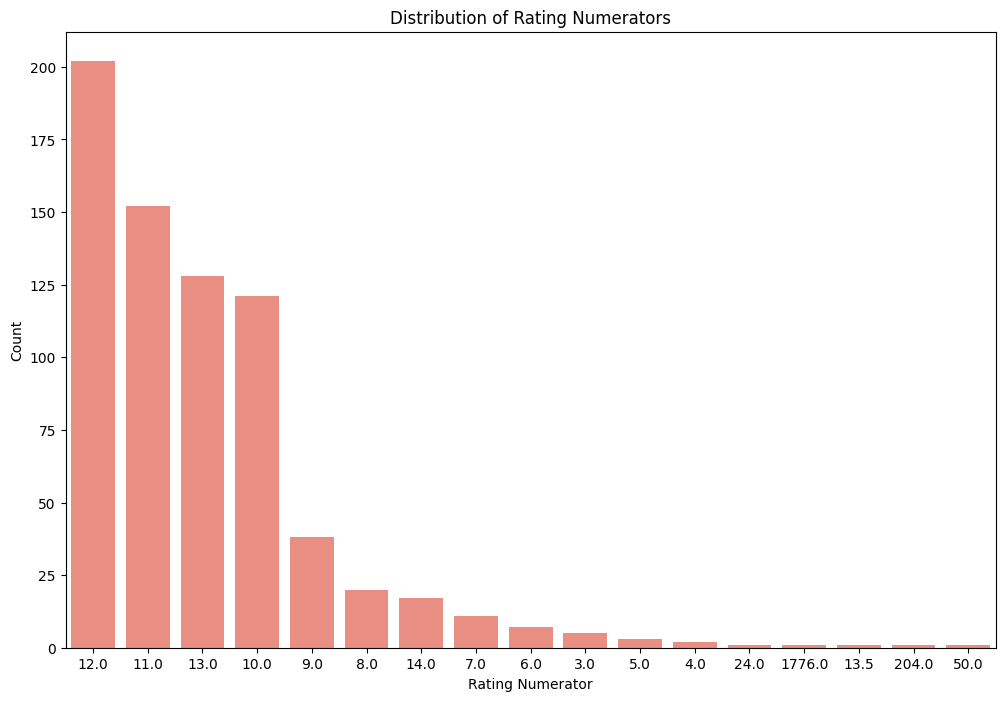

```python
from IPython import display
display.Image("./Dist of rating numerators.png")
```

### 3. Distribution of Retweet Count

This histogram displays the frequency of retweet count, noting the majority of the original tweets were retweeted about 3,000 or less times.

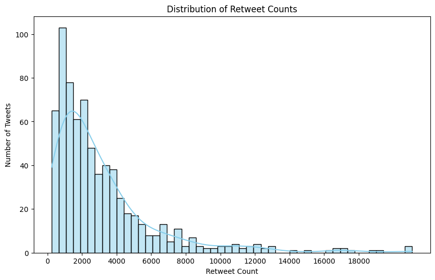

```python
from IPython import display
display.Image("./Dist of retweet counts.png")
```

### Conclusion

The insights and visualizations presented in this report offer a deeper understanding of the patterns within the WeRateDogs dataset. This analysis contributes valuable information for both dog enthusiasts and those interested in social media trends. The comprehensive approach to data wrangling and exploration enhances the reliability and applicability of the findings.